# L03 Variable Selection

Data Science 3 with R (STAT 301-3)

Author

Allison Kane

Published

April 15, 2024

**Github Repo Link**

[Allison Repo Link](https://github.com/stat301-3-2024-spring/L03-variable-selection-akane2460)

## Exercise

We will be re-visiting the rideshare dataset used in L02 Initial Setup. Find the `rideshare` dataset[^1] in the `\data` directory. Take a moment to read the variable definitions in `rideshare_codebook.txt`.

<sup>1</sup> Kaggle Uber & Lyft Dataset ([see website](https://www.kaggle.com/datasets/brllrb/uber-and-lyft-dataset-boston-ma))

**Prediction goal**

The objective is to predict the `price` of an Uber & Lyft rideshare.

### Getting Started

The initial setup has been completed for you using the following settings:

- read in data, converted character variables to factors, removed missingness issues with the outcome variable `price`.
- transformed the target variable `price` with a log10 transformation
- downsampled the dataset to 0.5% of the original data stratified by price for computation purposes
- implemented an 80-20 training-test split using stratified sampling (stratified by target variable with 4 strata)
- resamples were constructed by taking the training dataset and applying repeated V-fold cross-validation (5 folds, 3 repeat) with stratification on the target variable with 4 strata.
1. Run `1_initial_setup.R`.
2. After running the script the `data-splitting` directory should contain `rideshare_training.rda`, `rideshare_testing.rda`, and `rideshare_folds.rda`.
3. Check to see if any of these should be added to the `.gitignore` file.

### Task 1

Use lasso regression to perform variable selection.

- use a v-fold cross validation[^2]: 5 folds, 1 repeat, & stratify on on target variable
- use the `glmnet` engine
- tune the `penalty`
- use a regular grid of 5

<sup>2</sup> Different from the folds created in the initial setup and is done to guard against overfitting.

After finalizing and fitting the optimal lasso model, what variables were selected to include in your model?

**Solution**

The list of variables selected is: “hour”, “distance”, “longitude” “humidity”, “temperature_high_time”, “temperature_low_time”, “wind_bearing” “temperature_min”, “temperature_min_time”, “apparent_temperature_min_time”, “source”, “destination”, “product_id”, “name”, “short_summary”, “long_summary”, and “icon”

### Task 2

Use random forest to perform variable selection.

- use a v-fold cross validation[^3]: 5 folds, 1 repeat, & stratify on on target variable
- `ranger` engine
- in the engine set `importance = "impurity"` — this is what allows us to extract the variable importance
- tune `mtry` and `min_n`
- set `trees = 1000`
- use a regular grid with `levels = 4`

<sup>3</sup> Different from the folds created in the initial setup and is done to guard against overfitting.

After finalizing and fitting the optimal random forest model, select the top 20 important variables using `vip::vi()`. What variables were selected to include in your model?

**Solution**

The list of variables selected is: “distance”, cloud_cover”, “source”, “product_id”, “name”, “short_summary” and “icon”

### Task 3

Now that variable selection/screening has been completed we can proceed to feature engineering (recipe building).

Create 2 recipes:

1. The first should only use the variables selected by lasso regression in task 1
2. The second should only use the variables selected by the random forest variable importance in task 2.

**Note**

Both recipes should contain the standard minimal steps to run a recipe such as dummy encoding, handling zero variance, normalization (if appropriate).

**Solution**

The lasso recipe:

```r
# recipe with lasso variable selection
recipe_lasso <- recipe(price_log10 ~ ., data = rideshare_training) |>
  step_select(any_of( !!var_keep), price_log10) |>
  update_role(price, new_role = "original_scale") |>
  step_dummy(all_nominal_predictors()) |>
  step_nzv(all_predictors()) |>
  step_normalize(all_predictors())

# check recipe
recipe_lasso |>
  prep() |>
  bake(new_data = NULL) |>
  glimpse()

# save lasso recipe
load(here("recipes/recipe_lasso_rec1.rda"))

recipe_rf <- recipe(price_log10 ~ ., rideshare_training) |>
  step_select(all_of( !!var_keep_rf), price_log10) |>
  step_zv(all_predictors()) |>
  step_dummy(all_nominal_predictors(), one_hot = TRUE) |>
  step_normalize(all_numeric_predictors())

# check recipe
recipe_rf |>
  prep() |>
  bake(new_data = NULL) |>
  glimpse()

save(
  recipe_rf,
  file = here("recipes/recipe_rf_rec1.rda")
)
```

The random forest recipe:

```r
recipe_rf <- recipe(price_log10 ~ ., rideshare_training) |>
  step_select(all_of( !!var_keep_rf), price_log10) |>
  step_zv(all_predictors()) |>
  step_dummy(all_nominal_predictors(), one_hot = TRUE) |>
  step_normalize(all_numeric_predictors())

# check recipe
recipe_rf |>
  prep() |>
  bake(new_data = NULL) |>
  glimpse()

load(
  recipe_rf,
  file = here("recipes/recipe_rf_rec1.rda")
)
```

### Task 4

Fit each of the recipes to the following models and record computation time:

1. Support vector machine (polynomial): tune `cost`, `degree`, and `scale_factor` (default values are sufficient, free to change if you want)
2. Support vector machine (radial basis function): tune `cost` and `rbf_sigma` (default values a sufficient, free to change if you want)

Some general notes:

- A basic layout is suggested/provided in `4_tune_template.R`.
- We also want to collect how long it takes the tuning process for each model type. We can use the `tictoc` package — code is provided in `4_tune_template.R`.

### Task 5

Provide a nicely formatted table of model results. The table should include the model name, recipe name, best performance achieved, standard error of metric, and run time.

**Solution**

| model | recipe | mean | std_err | runtime |
| --- | --- | --- | --- | --- |
| svm_poly_lasso | lasso | 0.0686151 | 0.0011057 | 1322.305 |
| svm_poly_rf | rf | 0.0680830 | 0.0010929 | 760.084 |
| svm_radial_lasso | lasso | 0.0675649 | 0.0011411 | 803.768 |
| svm_radial_rf | rf | 0.0669690 | 0.0011615 | 749.595 |

### Task 6

Evaluate the best performing model on the testing data. This should include the interpretation of at least 2 metrics and a plot of observed vs predicted.

**Solution**

The random forest radial model is the best performing. Its performance metrics are below:

| .metric | .estimator | .estimate |
| --- | --- | --- |
| rmse | standard | 0.0673906 |
| rsq | standard | 0.9280035 |

The RMSE .0674 value indicates that the final model’s predictions on average deviated by .0674 units. The $R^2$ value indicates that approximately 92.8% of the variance in the target variable is explained by model. This indicates that the model’s performance is good.

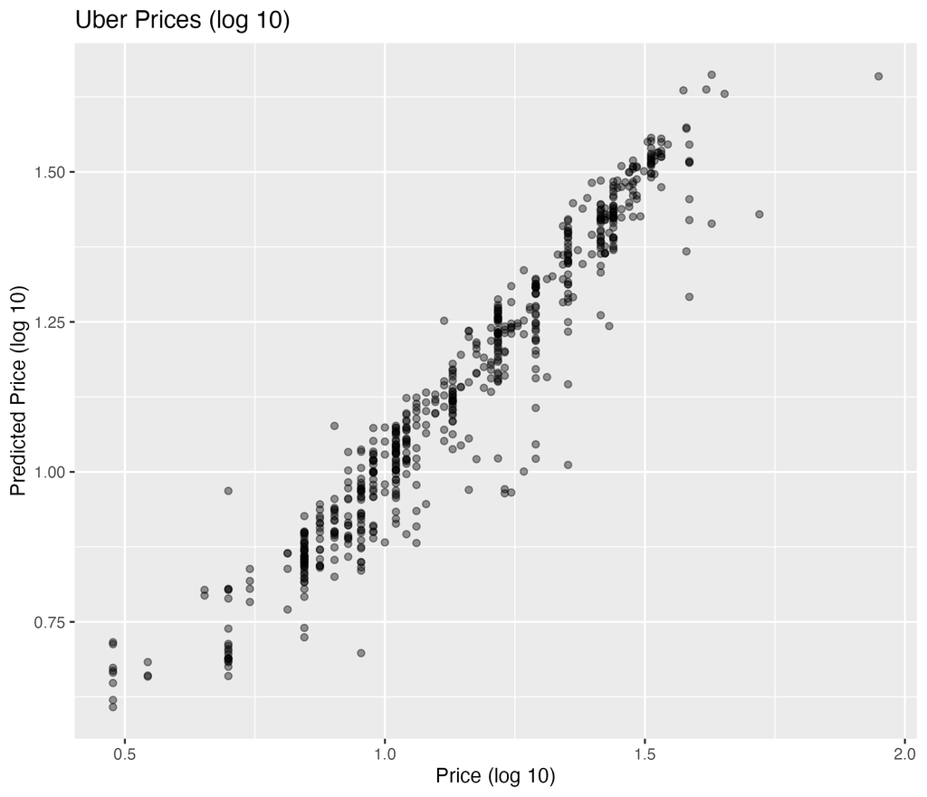

Predicted Uber Prices (log 10)

This plot indicates that most predictions of rideshare price are fairly reliable. Most predicted prices (log 10) nearly match the true value of the rideshare price (log 10).